# Latihan Terakhir TPG - Analisis Korespondensi

Rahmandani Bardianto G1401231029

2025-12-14

*Kasus* Kasus yang dianalisis adalah apakah jenis layanan transportasi (Kereta, Transjakarta, Angkot) berasosiasi dengan tingkat kepuasan (SangatTidakPuas, TidakPuas, Puas, SangatPuas). Data yang digunakan dibangkitkan di R menggunakan multinomial dengan total responden per layanan (Kereta=220, Transjakarta=200, Angkot=180) dan probabilitas kepuasan yang sengaja dibuat berbeda antar layanan untuk membentuk pola yang realistis; hasilnya membentuk tabel kontingensi 3×4

# 1 Generate data layanan transportasi vs kepuasan

```r
library(FactoMineR)
library(factoextra)
```

```r
library(gplots)
set.seed(123)


layanan = c("Kereta", "Transjakarta", "Angkot")
kepuasan = c("SangatTidakPuas", "TidakPuas", "Puas", "SangatPuas")

# Jumlah responden
nresponden = c(220, 200, 180)
names(nresponden) = layanan

probkereta = c(0.05, 0.10, 0.35, 0.50)
probtrans  = c(0.10, 0.20, 0.40, 0.30)
probangkot = c(0.40, 0.35, 0.20, 0.05)


kereta = as.vector(rmultinom(1, size = nresponden["Kereta"], prob = probkereta))
trans  = as.vector(rmultinom(1, size = nresponden["Transjakarta"], prob = probtrans))
angkot = as.vector(rmultinom(1, size = nresponden["Angkot"], prob = probangkot))

matriks = rbind(Kereta = kereta, Transjakarta = trans, Angkot = angkot)
colnames(matriks) = kepuasan

tablecount = as.table(matriks)
tablecount
```

```
##              SangatTidakPuas TidakPuas Puas SangatPuas
## Kereta                     9        26   75        110
## Transjakarta              27        34   92         47
## Angkot                    71        67   30         12
```

# 2 Balloon plot

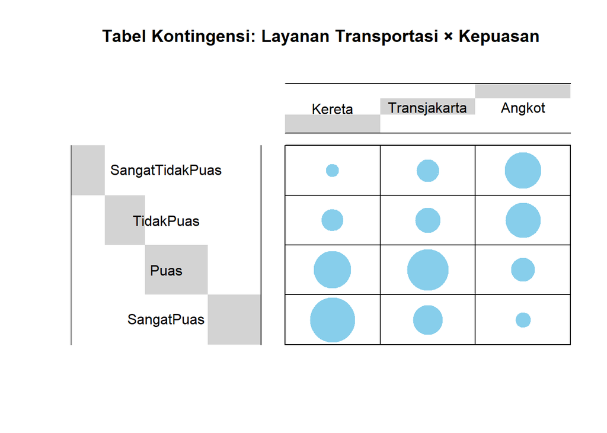

```r
balloonplot(
  tablecount,
  main = "Tabel Kontingensi: Layanan Transportasi × Kepuasan",
  xlab = "",
  ylab = "",
  label = FALSE,
  show.margins = FALSE
)
```

```r
proporsibaris = prop.table(tablecount, 1)
round(proporsibaris, 3)
```

```
##              SangatTidakPuas TidakPuas  Puas SangatPuas
## Kereta                 0.041     0.118 0.341      0.500
## Transjakarta           0.135     0.170 0.460      0.235
## Angkot                 0.394     0.372 0.167      0.067
```

Plot balloon menunjukkan pola yang jelas dari tabel kontingensi Layanan Transportasi × Kepuasan: ukuran lingkaran merepresentasikan frekuensi, jadi sel dengan lingkaran paling besar adalah kombinasi yang paling sering muncul. Terlihat Kereta didominasi oleh kategori Puas dan terutama Sangat Puas (lingkaran besar di dua baris bawah), sementara pada Sangat Tidak Puas dan Tidak Puas lingkarannya kecil—artinya keluhan relatif sedikit. Transjakarta paling menonjol di kategori Puas (lingkaran besar), dengan Tidak Puas dan Sangat Tidak Puas masih ada tapi tidak sebesar Angkot, dan Sangat Puas relatif lebih kecil dibanding Kereta. Sebaliknya, Angkot paling kuat pada Sangat Tidak Puas dan Tidak Puas (lingkaran terbesar di dua baris atas), sedangkan pada Puas dan terutama Sangat Puas lingkarannya kecil—menandakan kepuasan tinggi jarang terjadi pada Angkot. Ini sudah memberi sinyal kuat bahwa tingkat kepuasan berbeda menurut layanan (tidak “rata”/independen).

# 3 Chi-square test

```r
chisq = chisq.test(tablecount)
chisq
```

```
##
##  Pearson's Chi-squared test
##
## data:  tablecount
## X-squared = 198.5, df = 6, p-value < 2.2e-16
```

*Hasil chi square test* Pearson’s Chi-squared test menunjukkan bahwa jenis layanan transportasi dan tingkat kepuasan tidak independen. Nilai statistik uji X² = 198,5 dengan df = 6 menghasilkan p-value < 2,2×10⁻¹⁶, jauh di bawah taraf nyata umum (mis. 0,05), sehingga H₀ (tidak ada hubungan/asosiasi) ditolak. Artinya, distribusi kepuasan berbeda nyata antar layanan (Kereta, Transjakarta, Angkot), konsisten dengan pola pada tabel/balloon plot bahwa beberapa kombinasi layanan–kepuasan muncul jauh lebih sering daripada yang diharapkan jika keduanya tidak terkait.

# 4 Correspondence Analysis

```r
modelca = CA(tablecount, graph = FALSE)
print(modelca)
```

```
## **Results of the Correspondence Analysis (CA)**
## The row variable has  3  categories; the column variable has 4 categories
## The chi square of independence between the two variables is equal to 198.5037 (p-value =  3.950558e-40 ).
## *The results are available in the following objects:
##
##    name              description
## 1  "$eig"            "eigenvalues"
## 2  "$col"            "results for the columns"
## 3  "$col$coord"      "coord. for the columns"
## 4  "$col$cos2"       "cos2 for the columns"
## 5  "$col$contrib"    "contributions of the columns"
## 6  "$row"            "results for the rows"
## 7  "$row$coord"      "coord. for the rows"
## 8  "$row$cos2"       "cos2 for the rows"
## 9  "$row$contrib"    "contributions of the rows"
## 10 "$call"           "summary called parameters"
## 11 "$call$marge.col" "weights of the columns"
## 12 "$call$marge.row" "weights of the rows"
```

# 5 Eigenvalues and Scree plot

```r
eigval = get_eigenvalue(modelca)
eigval
```

```
##       eigenvalue variance.percent cumulative.variance.percent
## Dim.1 0.29696370         89.76064                    89.76064
## Dim.2 0.03387587         10.23936                   100.00000
```

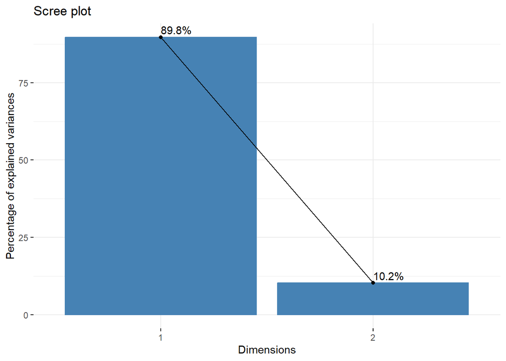

```r
fviz_screeplot(modelca, addlabels = TRUE)
```

# 6 profil baris (layanan)

```r
baris = get_ca_row(modelca)
baris$coord
```

```
##                   Dim 1       Dim 2
## Kereta       -0.5400644  0.15887391
## Transjakarta -0.1139929 -0.25742845
## Angkot        0.7867375  0.09185239
```

```r
baris$contrib
```

```
##                  Dim 1     Dim 2
## Kereta       36.012985 27.320348
## Transjakarta  1.458582 65.208084
## Angkot       62.528432  7.471568
```

```r
baris$cos2
```

```
##                  Dim 1      Dim 2
## Kereta       0.9203531 0.07964685
## Transjakarta 0.1639384 0.83606158
## Angkot       0.9865525 0.01344750
```

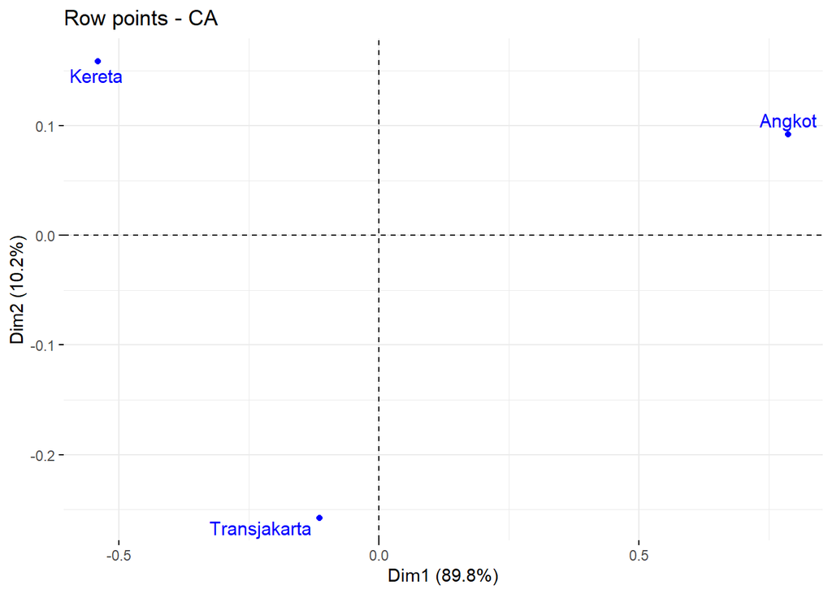

```r
fviz_ca_row(modelca, repel = TRUE)
```

# 7 profil kolom (kepuasan)

```r
kolom = get_ca_col(modelca)
kolom$coord
```

```
##                      Dim 1       Dim 2
## SangatTidakPuas  0.8218283  0.05081892
## TidakPuas        0.5027461  0.06555182
## Puas            -0.2551379 -0.24855605
## SangatPuas      -0.6007232  0.20830081
```

```r
kolom$contrib
```

```
##                     Dim 1     Dim 2
## SangatTidakPuas 40.559383  1.359543
## TidakPuas       18.015505  2.684921
## Puas             7.197165 59.878823
## SangatPuas      34.227947 36.076713
```

```r
kolom$cos2
```

```
##                     Dim 1       Dim 2
## SangatTidakPuas 0.9961908 0.003809178
## TidakPuas       0.9832833 0.016716710
## Puas            0.5130649 0.486935122
## SangatPuas      0.8926694 0.107330650
```

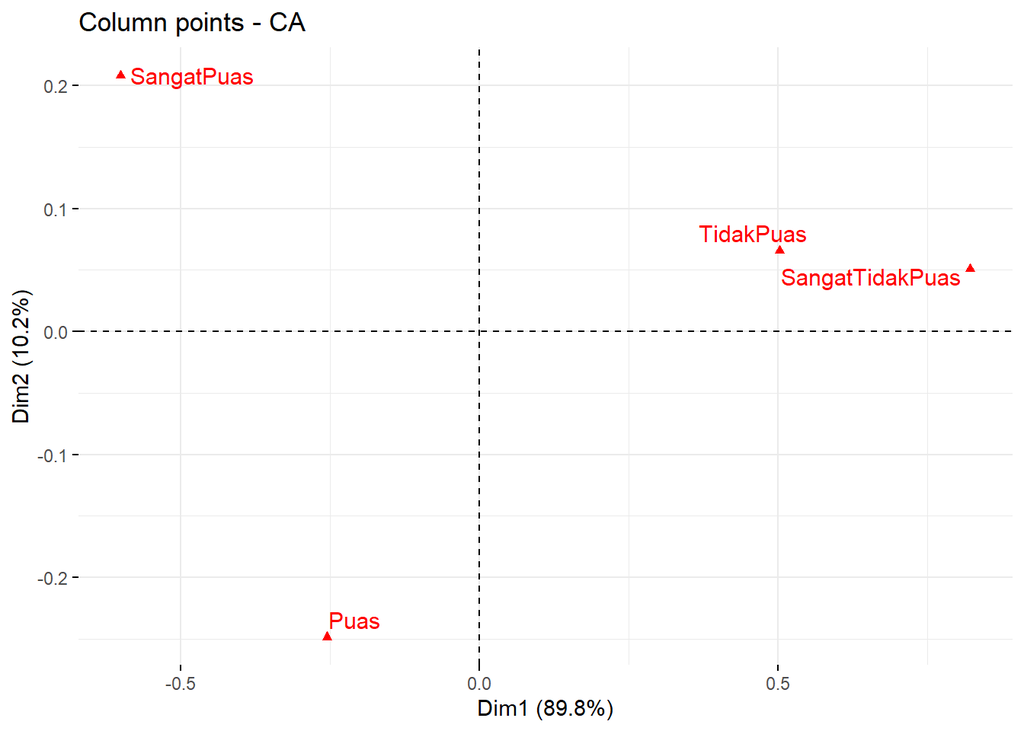

```r
fviz_ca_col(modelca, repel = TRUE)
```

# 8 Biplot analisis korespondensi

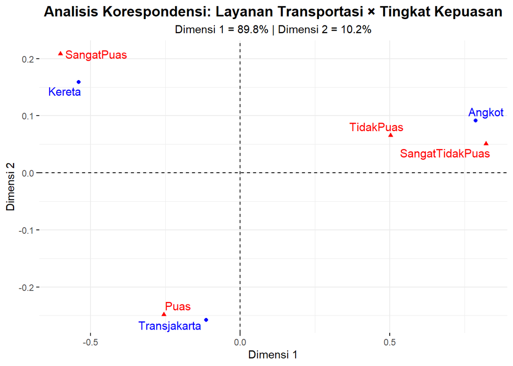

```r
persen1 = modelca$eig[1,2]
persen2 = modelca$eig[2,2]

judulutama = "Analisis Korespondensi: Layanan Transportasi × Tingkat Kepuasan"
subjudul = sprintf("Dimensi 1 = %.1f%% | Dimensi 2 = %.1f%%", persen1, persen2)

plotca =
  fviz_ca_biplot(modelca, repel = TRUE, title = "") +
  labs(title = judulutama, subtitle = subjudul, x = "Dimensi 1", y = "Dimensi 2") +
  theme(
    plot.title = element_text(hjust = 0.5, face = "bold", size = 14),
    plot.subtitle = element_text(hjust = 0.5, size = 11),
    legend.position = "none"
  )

plotca
```

*Interpretasi Plot Korespondensi* Biplot CA menunjukkan pemetaan hubungan antara layanan transportasi dan tingkat kepuasan pada dua dimensi. Dimensi 1 menjelaskan 89,8% keragaman asosiasi, sedangkan Dimensi 2 menjelaskan 10,2%, sehingga dua dimensi sudah mewakili hampir seluruh informasi. Titik Kereta berada berdekatan dengan kategori Sangat Puas, yang mengindikasikan responden Kereta lebih sering berada pada kepuasan sangat tinggi. Titik Angkot berada dekat dengan kategori Sangat Tidak Puas dan searah dengan Tidak Puas, yang menunjukkan Angkot cenderung berkaitan dengan tingkat ketidakpuasan. Titik Transjakarta berada dekat dengan kategori Puas, sehingga pola kepuasan Transjakarta lebih banyak terkonsentrasi pada tingkat puas (menengah) dibanding sangat puas. Secara keseluruhan, Kereta terkait dengan kepuasan tinggi, Angkot terkait dengan ketidakpuasan, dan Transjakarta berada di antara keduanya.

# 9 Kesimpulan

analisis korespondensi pada data kontingensi Layanan Transportasi (Kereta, Transjakarta, Angkot) × Tingkat Kepuasan (SangatTidakPuas–SangatPuas) menunjukkan bahwa tingkat kepuasan pengguna berbeda nyata antar layanan. Pola pada tabel/balloon plot memperlihatkan Kereta lebih sering muncul pada kategori Puas dan terutama Sangat Puas, Transjakarta cenderung terkonsentrasi pada kategori Puas, sedangkan Angkot dominan pada Tidak Puas dan Sangat Tidak Puas. Hasil ini diperkuat oleh uji Pearson chi-square (X² = 198,5; df = 6; p-value < 2,2×10⁻¹⁶) yang menegaskan adanya keterkaitan signifikan antara layanan dan kepuasan. Pemetaan melalui CA juga konsisten: dua dimensi sudah memadai (Dimensi 1 = 89,8% dan Dimensi 2 = 10,2%), dengan Kereta berada dekat Sangat Puas, Angkot dekat Sangat Tidak Puas/Tidak Puas, dan Transjakarta dekat Puas. Dengan demikian, kepuasan pengguna tidak bersifat independen terhadap jenis layanan; Kereta terkait dengan kepuasan tinggi, Angkot terkait dengan ketidakpuasan, dan Transjakarta berada pada tingkat kepuasan menengah.